AS.430.271.81: M07 - Adam Thomas

# M07 Homework - AdaBoost

This JupyterLab Notebook will implement the following tasks:

- Load the NYC taxi data from [here](https://www.kaggle.com/c/nyc-taxi-trip-duration/data)
- Filter anomalous records
- Clip data to NYC shoreline
- Create interpretable columns for machine learning (convert datetime and lat/lon values to hour of day, day of week, and distance)
- Predict taxi trip durations using AdaBoost

```python
import warnings
warnings.filterwarnings("ignore", category=DeprecationWarning)
```

```python
import colorcet
import datashader
import gc
import geopandas as gpd
import matplotlib.pyplot as plt
import numpy as np
import pandas as pd
from sklearn import model_selection, metrics
from sklearn.datasets import make_regression
from sklearn.ensemble import AdaBoostRegressor
from sklearn.model_selection import RandomizedSearchCV
from sklearn.tree import DecisionTreeRegressor
```

## Load NYC Taxi Data

Inspect initial data

```python
df = pd.read_csv('train.csv')
df.head()
```

|  | id | vendor_id | pickup_datetime | dropoff_datetime | passenger_count | pickup_longitude | pickup_latitude | dropoff_longitude | dropoff_latitude | store_and_fwd_flag | trip_duration |
| --- | --- | --- | --- | --- | --- | --- | --- | --- | --- | --- | --- |
| 0 | id2875421 | 2 | 2016-03-14 17:24:55 | 2016-03-14 17:32:30 | 1 | -73.982155 | 40.767937 | -73.964630 | 40.765602 | N | 455 |
| 1 | id2377394 | 1 | 2016-06-12 00:43:35 | 2016-06-12 00:54:38 | 1 | -73.980415 | 40.738564 | -73.999481 | 40.731152 | N | 663 |
| 2 | id3858529 | 2 | 2016-01-19 11:35:24 | 2016-01-19 12:10:48 | 1 | -73.979027 | 40.763939 | -74.005333 | 40.710087 | N | 2124 |
| 3 | id3504673 | 2 | 2016-04-06 19:32:31 | 2016-04-06 19:39:40 | 1 | -74.010040 | 40.719971 | -74.012268 | 40.706718 | N | 429 |
| 4 | id2181028 | 2 | 2016-03-26 13:30:55 | 2016-03-26 13:38:10 | 1 | -73.973053 | 40.793209 | -73.972923 | 40.782520 | N | 435 |

Inspect dtypes and non-null counts

```python
df.info()
```

```
<class 'pandas.core.frame.DataFrame'>
RangeIndex: 1458644 entries, 0 to 1458643
Data columns (total 11 columns):
 #   Column              Non-Null Count    Dtype
---  ------              --------------    -----
 0   id                  1458644 non-null  object
 1   vendor_id           1458644 non-null  int64
 2   pickup_datetime     1458644 non-null  object
 3   dropoff_datetime    1458644 non-null  object
 4   passenger_count     1458644 non-null  int64
 5   pickup_longitude    1458644 non-null  float64
 6   pickup_latitude     1458644 non-null  float64
 7   dropoff_longitude   1458644 non-null  float64
 8   dropoff_latitude    1458644 non-null  float64
 9   store_and_fwd_flag  1458644 non-null  object
 10  trip_duration       1458644 non-null  int64
dtypes: float64(4), int64(3), object(4)
memory usage: 122.4+ MB
```

Convert pickup_datetime and dropoff_datetime to datetime types

```python
df[['pickup_datetime', 'dropoff_datetime']] = df[['pickup_datetime', 'dropoff_datetime']].apply(pd.to_datetime)
```

Inspect data statistics

```python
df.describe()
```

|  | vendor_id | passenger_count | pickup_longitude | pickup_latitude | dropoff_longitude | dropoff_latitude | trip_duration |
| --- | --- | --- | --- | --- | --- | --- | --- |
| count | 1.458644e+06 | 1.458644e+06 | 1.458644e+06 | 1.458644e+06 | 1.458644e+06 | 1.458644e+06 | 1.458644e+06 |
| mean | 1.534950e+00 | 1.664530e+00 | -7.397349e+01 | 4.075092e+01 | -7.397342e+01 | 4.075180e+01 | 9.594923e+02 |
| std | 4.987772e-01 | 1.314242e+00 | 7.090186e-02 | 3.288119e-02 | 7.064327e-02 | 3.589056e-02 | 5.237432e+03 |
| min | 1.000000e+00 | 0.000000e+00 | -1.219333e+02 | 3.435970e+01 | -1.219333e+02 | 3.218114e+01 | 1.000000e+00 |
| 25% | 1.000000e+00 | 1.000000e+00 | -7.399187e+01 | 4.073735e+01 | -7.399133e+01 | 4.073588e+01 | 3.970000e+02 |
| 50% | 2.000000e+00 | 1.000000e+00 | -7.398174e+01 | 4.075410e+01 | -7.397975e+01 | 4.075452e+01 | 6.620000e+02 |
| 75% | 2.000000e+00 | 2.000000e+00 | -7.396733e+01 | 4.076836e+01 | -7.396301e+01 | 4.076981e+01 | 1.075000e+03 |
| max | 2.000000e+00 | 9.000000e+00 | -6.133553e+01 | 5.188108e+01 | -6.133553e+01 | 4.392103e+01 | 3.526282e+06 |

There are a few noticable data anomalies, let's remove these next.

## Filter / Clean Data

First, let's remove trips that have zero passengers

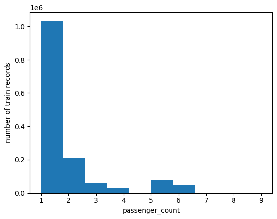

```python
df = df[df['passenger_count'] > 0]
plt.hist(df['passenger_count'].values, bins=10)
plt.xlabel('passenger_count')
plt.ylabel('number of train records')
plt.show()
```

Now let's take a look at the trip duration data to see if there are any anomalies

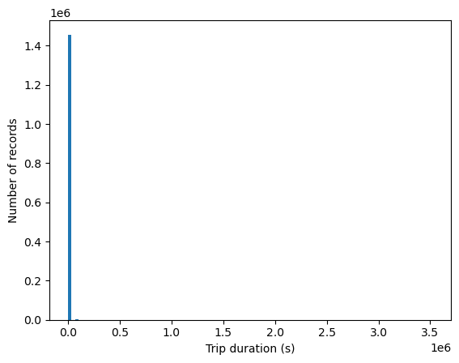

```python
# Plot histogram of trips
plt.hist(df['trip_duration'].values, bins=100)
plt.xlabel('Trip duration (s)')
plt.ylabel('Number of records')
plt.show()
```

Something does not look right. Let's view the same data as a box plot to see what is going on

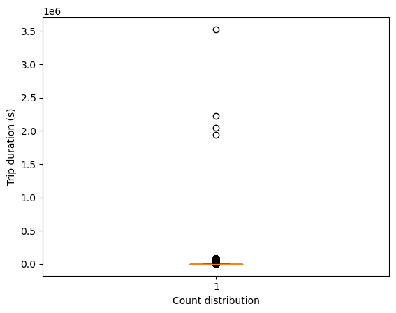

```python
plt.boxplot(df['trip_duration'])
plt.xlabel('Count distribution')
plt.ylabel('Trip duration (s)')
plt.show()
```

This data is does not have a normal distribution, but already has some obvious outliers. Let's look at a logarithmic version

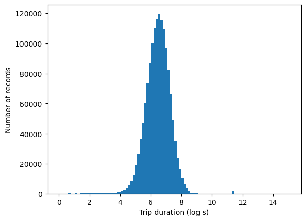

```python
df['trip_duration_log'] = np.log(df['trip_duration'].values)
plt.hist(df['trip_duration_log'], bins=100)
plt.xlabel('Trip duration (log s)')
plt.ylabel('Number of records')
plt.show()
```

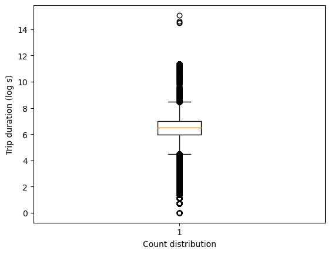

```python
plt.boxplot(df['trip_duration_log'])
plt.xlabel('Count distribution')
plt.ylabel('Trip duration (log s)')
plt.show()
```

There are clearly some outliers at the extreme ends of the data, so let's only include everything within 2 standard deviations of the logarithmic mean.

```python
m = np.mean(df['trip_duration_log'])
s = np.std(df['trip_duration_log'])
df = df[df['trip_duration_log'] <= m + (2*s)]
df = df[df['trip_duration_log'] >= m - (2*s)]
```

Now let's see how the logarithmic distribution has changed

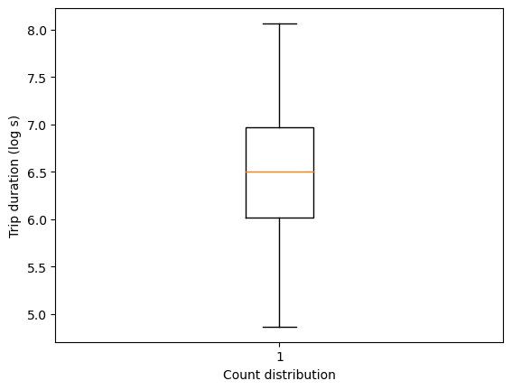

```python
plt.boxplot(df['trip_duration_log'].values)
plt.xlabel('Count distribution')
plt.ylabel('Trip duration (log s)')
plt.show()
```

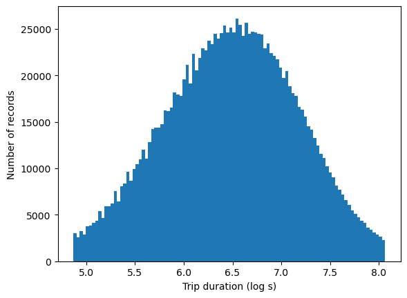

```python
# df['trip_duration_log'] = np.log(df['trip_duration'].values)
plt.hist(df['trip_duration_log'], bins=100)
plt.xlabel('Trip duration (log s)')
plt.ylabel('Number of records')
plt.show()
```

The logarithmic blox plot and histogram plot above is much cleaner than before. Let's plot the original trip duration historgram now that the outliers have been removed.

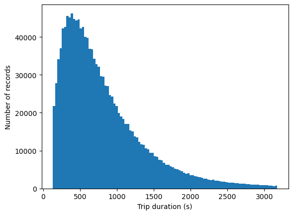

```python
plt.hist(df['trip_duration'].values, bins=100)
plt.xlabel('Trip duration (s)')
plt.ylabel('Number of records')
plt.show()
```

```python
df.describe()
```

|  | vendor_id | passenger_count | pickup_longitude | pickup_latitude | dropoff_longitude | dropoff_latitude | trip_duration | trip_duration_log |
| --- | --- | --- | --- | --- | --- | --- | --- | --- |
| count | 1.405870e+06 | 1.405870e+06 | 1.405870e+06 | 1.405870e+06 | 1.405870e+06 | 1.405870e+06 | 1.405870e+06 | 1.405870e+06 |
| mean | 1.534867e+00 | 1.665491e+00 | -7.397474e+01 | 4.075137e+01 | -7.397402e+01 | 4.075206e+01 | 8.159133e+02 | 6.488958e+00 |
| std | 4.987830e-01 | 1.314766e+00 | 7.006791e-02 | 3.185845e-02 | 7.009733e-02 | 3.500508e-02 | 5.530488e+02 | 6.678924e-01 |
| min | 1.000000e+00 | 1.000000e+00 | -1.219333e+02 | 3.435970e+01 | -1.219333e+02 | 3.218114e+01 | 1.300000e+02 | 4.867534e+00 |
| 25% | 1.000000e+00 | 1.000000e+00 | -7.399197e+01 | 4.073762e+01 | -7.399136e+01 | 4.073611e+01 | 4.100000e+02 | 6.016157e+00 |
| 50% | 2.000000e+00 | 1.000000e+00 | -7.398192e+01 | 4.075414e+01 | -7.397985e+01 | 4.075455e+01 | 6.680000e+02 | 6.504288e+00 |
| 75% | 2.000000e+00 | 2.000000e+00 | -7.396796e+01 | 4.076828e+01 | -7.396338e+01 | 4.076974e+01 | 1.065000e+03 | 6.970730e+00 |
| max | 2.000000e+00 | 9.000000e+00 | -6.133553e+01 | 5.188108e+01 | -6.133553e+01 | 4.391176e+01 | 3.175000e+03 | 8.063063e+00 |

## Clip Data to NYC shoreline

Some of the taxi data is in the water, so let's clip to the land boundary

```python
# Remove trips that are outside a smaller bounding box covering NYC
# Remove trips that have the same pickup and dropoff coordinates

xmin,ymin,xmax,ymax = [-74.021072,40.698340,-73.927002,40.851995]
df = df[(df['pickup_latitude'].between(ymin,ymax)) &
        (df['pickup_longitude'].between(xmin,xmax)) &
        (df['dropoff_latitude'].between(ymin,ymax)) &
        (df['dropoff_longitude'].between(xmin,xmax)) &
        (df['pickup_latitude'] != df['dropoff_latitude']) &
        (df['pickup_longitude'] != df['dropoff_longitude'])]
```

```python
# Now clip pickup and dropoff locations to within detailed shoreline
land_boundary = gpd.read_file('State_Shorline_LL84.shp')

temp_df = gpd.GeoDataFrame(df, geometry=gpd.points_from_xy(df.pickup_longitude, df.pickup_latitude), crs=f"EPSG:4326").clip(land_boundary)
clean_df = gpd.GeoDataFrame(temp_df, geometry=gpd.points_from_xy(temp_df.dropoff_longitude, temp_df.dropoff_latitude), crs=f"EPSG:4326").clip(land_boundary)

# clear some memory
del df
del temp_df
gc.collect()
```

```
0
```

Plot visual aggregation of pickup locations to inspect geographically

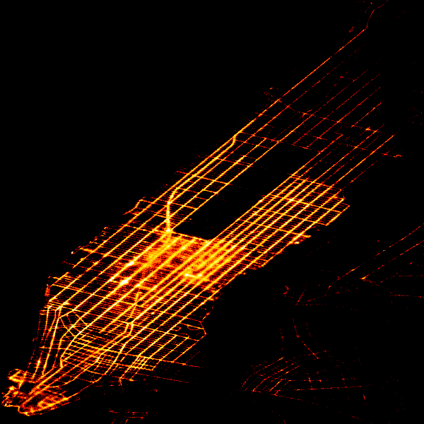

```python
aggregated = datashader.Canvas().points(clean_df, 'pickup_longitude', 'pickup_latitude')
datashader.tf.set_background(datashader.tf.shade(aggregated, cmap=colorcet.fire), "black")
```

## Create Interpretable Columns

Before starting a training model, I will create different columns to represent time and location instead of using datetime and lat/lon. These will be hour of day, day of week, and distance.

```python
# hour of day based on pickup location
clean_df['hour'] = clean_df['pickup_datetime'].dt.hour

# day of week based on pickup location
clean_df['day'] = clean_df['pickup_datetime'].dt.dayofweek
```

Unfortunately the hour and day values create jump discontinuities, meaning that values like 11pm (23) and midnight (0) differ by 23, but are actually more similar in value than midnight (0) and 6am (6). We can solve this by converting hour and day to cyclical values

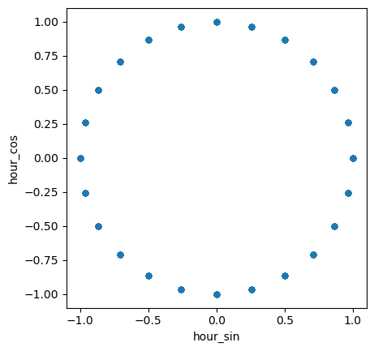

```python
# Convert hour to hour_sin and hour_cos
clean_df['hour_sin'] = np.sin(2 * np.pi * clean_df['hour']/24.0)
clean_df['hour_cos'] = np.cos(2 * np.pi * clean_df['hour']/24.0)
# Plot cyclical pattern of hour
clean_df.plot.scatter('hour_sin', 'hour_cos').set_aspect('equal')
```

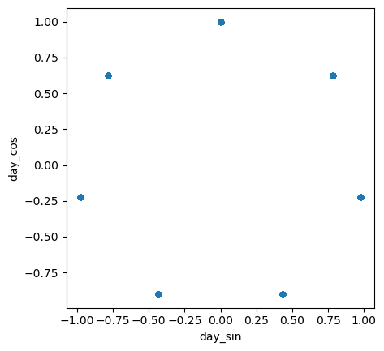

```python
# Convert day to day_sin and day_cos
clean_df['day_sin'] = np.sin(2 * np.pi * clean_df['day']/7.0)
clean_df['day_cos'] = np.cos(2 * np.pi * clean_df['day']/7.0)
# Plot cyclical pattern of day
clean_df.plot.scatter('day_sin', 'day_cos').set_aspect('equal')
```

These are the results we are looking for. Times and days that are more similar to one another are now closer together in value.

```python
# Add a distance column to the cleaned dataframe based on the haversince function found here: https://stackoverflow.com/questions/29545704/fast-haversine-approximation-python-pandas/29546836#29546836
# Using the mean of the min and max radii of the Earth as 6,367.4445

def haversine_distance(lon1: pd.Series, lat1: pd.Series, lon2: pd.Series, lat2: pd.Series) -> pd.Series:
    """
    Calculate the great circle distance between two points
    on the earth (specified in decimal degrees)

    All args must be of equal length.

    """
    lon1, lat1, lon2, lat2 = map(np.radians, [lon1, lat1, lon2, lat2])

    dlon = lon2 - lon1
    dlat = lat2 - lat1

    a = np.sin(dlat/2.0)**2 + np.cos(lat1) * np.cos(lat2) * np.sin(dlon/2.0)**2

    c = 2 * np.arcsin(np.sqrt(a))
    km = 6367.4445 * c
    return km

clean_df['distance_km'] = haversine_distance(clean_df['pickup_longitude'],clean_df['pickup_latitude'],clean_df['dropoff_longitude'],clean_df['dropoff_latitude'])
```

Create final dataframe with the columns we want in the training model

```python
final_df = clean_df[['pickup_longitude','pickup_latitude','dropoff_longitude','dropoff_latitude','passenger_count','hour_sin', 'hour_cos', 'day_sin', 'day_cos', 'distance_km', 'trip_duration']]

# clear some memory
del clean_df
gc.collect()
```

```
3853
```

```python
final_df.describe()
```

|  | pickup_longitude | pickup_latitude | dropoff_longitude | dropoff_latitude | passenger_count | hour_sin | hour_cos | day_sin | day_cos | distance_km | trip_duration |
| --- | --- | --- | --- | --- | --- | --- | --- | --- | --- | --- | --- |
| count | 1.225582e+06 | 1.225582e+06 | 1.225582e+06 | 1.225582e+06 | 1.225582e+06 | 1.225582e+06 | 1.225582e+06 | 1.225582e+06 | 1.225582e+06 | 1.225582e+06 | 1.225582e+06 |
| mean | -7.398142e+01 | 4.075396e+01 | -7.397982e+01 | 4.075514e+01 | 1.662756e+00 | -2.121681e-01 | -1.106450e-01 | -7.519182e-05 | -4.565394e-02 | 2.411175e+00 | 7.116099e+02 |
| std | 1.639671e-02 | 2.171501e-02 | 1.774466e-02 | 2.415352e-02 | 1.313313e+00 | 6.721468e-01 | 7.006867e-01 | 7.116431e-01 | 7.010568e-01 | 1.743775e+00 | 4.377486e+02 |
| min | -7.401842e+01 | 4.069835e+01 | -7.401851e+01 | 4.069834e+01 | 1.000000e+00 | -1.000000e+00 | -1.000000e+00 | -9.749279e-01 | -9.009689e-01 | 7.692991e-04 | 1.300000e+02 |
| 25% | -7.399249e+01 | 4.073949e+01 | -7.399194e+01 | 4.073937e+01 | 1.000000e+00 | -8.660254e-01 | -7.071068e-01 | -7.818315e-01 | -9.009689e-01 | 1.200319e+00 | 3.860000e+02 |
| 50% | -7.398242e+01 | 4.075476e+01 | -7.398124e+01 | 4.075553e+01 | 1.000000e+00 | -2.588190e-01 | -2.588190e-01 | 0.000000e+00 | -2.225209e-01 | 1.903213e+00 | 6.100000e+02 |
| 75% | -7.397079e+01 | 4.076787e+01 | -7.396809e+01 | 4.077001e+01 | 2.000000e+00 | 2.588190e-01 | 5.000000e-01 | 7.818315e-01 | 6.234898e-01 | 3.079891e+00 | 9.290000e+02 |
| max | -7.392701e+01 | 4.085198e+01 | -7.392701e+01 | 4.085199e+01 | 6.000000e+00 | 1.000000e+00 | 1.000000e+00 | 9.749279e-01 | 1.000000e+00 | 1.766308e+01 | 3.175000e+03 |

Looking good and ready to train the model

## Predict Taxi Trip Duration using AdaBoost

Create training and validation data

```python
X = final_df.iloc[:,:-1]  # Everything but the last column
y = final_df.iloc[:,-1]  # The last column

# Split input and output based on 25% test size
X_train, X_test, y_train, y_test = model_selection.train_test_split(X, y, test_size=0.25)
```

```python
adaboost = AdaBoostRegressor(estimator=DecisionTreeRegressor(max_depth=3), n_estimators=200, learning_rate=0.01, random_state=42)
```

```python
adaboost.fit(X_train, y_train)
```

[output not shown]

```python
ada_predictions = adaboost.predict(X_test)
#show score from each prediction round
# for i in adaboost.staged_predict(X_test):
#     print(f'Score: {adaboost.score(X_test, i)}')
```

```python
# Print metrics
print(f'r2: {metrics.r2_score(y_test, ada_predictions)}')
print(f'rmse: {np.sqrt(metrics.mean_squared_error(y_test, ada_predictions))}')
```

```
r2: 0.48852318204461
rmse: 312.8665807180896
```

These results don't looks great. Let's see if we can get them better by tuning the regression hyperparameters

## Hypertune the AdaBoost Model

Let's take a look at a variety of hyperparameters and see which combination works better, at least for a random subset.

```python
# X_train_sample = X_train.sample(frac=0.1)
# y_train_sample = y_train.sample(frac=0.1)

adaboost = AdaBoostRegressor()
param_grid = {"n_estimators": [50, 100, 200, 500],
              "learning_rate": [0.01, 0.025, 0.05, 0.1],
              "estimator": [DecisionTreeRegressor(max_depth=3), DecisionTreeRegressor(max_depth=4), DecisionTreeRegressor(max_depth=5), DecisionTreeRegressor(max_depth=6)]}
search = RandomizedSearchCV(adaboost, param_grid, scoring='r2', n_jobs=-1).fit(X_train, y_train)
print("The best hyperparameters are ",search.best_params_)
```

```
The best hyperparameters are  {'n_estimators': 50, 'learning_rate': 0.025, 'estimator': DecisionTreeRegressor(max_depth=6)}
```

Now let's re-run the model using the best combination of hyperparameters

```python
adaboost = AdaBoostRegressor(learning_rate = search.best_params_["learning_rate"],
                             n_estimators  = search.best_params_["n_estimators"],
                             estimator = search.best_params_["estimator"])
```

```python
adaboost.fit(X_train, y_train)
```

```
AdaBoostRegressor(estimator=DecisionTreeRegressor(max_depth=6),
                  learning_rate=0.025)
```

```python
ada_predictions = adaboost.predict(X_test)
```

```python
# Print metrics
print(f'r2: {metrics.r2_score(y_test, ada_predictions)}')
print(f'rmse: {np.sqrt(metrics.mean_squared_error(y_test, ada_predictions))}')
```

```
r2: 0.5741488144288887
rmse: 285.47963239797093
```

By tuning the hyperparameters in the model, the resulting metrics were greatly improved.